# Soil Organic Carbon Stocks

J. Nemecek, S.A. Wills, and C. Ferguson

First created on 2017-11-12. Updated on 2021-04-12

# Soil Organic Carbon Stocks by Landunit

[SQL Script Soil Organic Carbon Stock](https://github.com/jneme910/CART/blob/master/SQL-Library/SDA_CART_SoilsQuery_kitchensink_20190612.txt)

This query runs through the Soil Data Access tabular data query portal. The portal queries current databases maintained by the U.S. National Cooperative Soil Survey.

Soil organic carbon (SOC) stocks are estimates of the total mass of SOC in a soil profile for a given depth (0 cm up to the depth of the soil profile). SOC stocks in each soil component and map unit are expressed in metric tons (Mg) per hectare for predetermined depth increments. Null values are presented where data are incomplete or not available.

General information about this query:

$$Layer\ SOC\ stock = (hz_{T} * ( ( om / 1.724 ) * db3 ) * (100.0 - fragvol) / 100.0)$$

where `hz_{T}` = horizon thickness, `om` = organic matter, `db3` = bulk density and `fragvol` = coarse fragment volume.

## Rating Class and Values

| Rating Class | Value Range |
| --- | --- |
| Very Low | >0 to <10 |
| Low | >=10 to 25 |
| Moderate | >=25 to <50 |
| Moderately High | >=50 to 100 |
| High | >100 |

#### Insert identifier(s) string and WKT geometry for each area of interest (AOI) polygon

```sql
SELECT @aoiGeom = GEOMETRY::STGeomFromText('MULTIPOLYGON (((-102.12335160658608 45.959173206572416, -102.13402890980223 45.959218442561564, -102.13386921506947 45.944643788188387, -102.12327175652177 45.944703605814198, -102.12335160658608 45.959173206572416)))', 4326);
SELECT @aoiGeomFixed = @aoiGeom.MakeValid().STUnion(@aoiGeom.STStartPoint());
INSERT INTO #AoiTable ( landunit, aoigeom )
VALUES ('T9981 Fld3', @aoiGeomFixed);
SELECT @aoiGeom = GEOMETRY::STGeomFromText('MULTIPOLYGON (((-102.1130336443976 45.959162795100383, -102.12335160658608 45.959173206572416, -102.12327175652177 45.944703605814198, -102.1128892282776 45.944710506326032, -102.1130336443976 45.959162795100383)))', 4326);
SELECT @aoiGeomFixed = @aoiGeom.MakeValid().STUnion(@aoiGeom.STStartPoint());
INSERT INTO #AoiTable ( landunit, aoigeom )
VALUES ('T9981 Fld4', @aoiGeomFixed);
```

| aoiid | landunit | aoigeom |
| --- | --- | --- |
| 1 | T9981 Fld3 | POLYGON ((-102.13386921506947 45.944643788188387, -102.12327175652177 45.9447036058142, -102.12335160658608 45.959173206572416, -102.13402890980223 45.959218442561564, -102.13386921506947 45.944643788… |
| 2 | T9981 Fld4 | POLYGON ((-102.12327175652177 45.9447036058142, -102.1128892282776 45.944710506326032, -102.1130336443976 45.959162795100383, -102.12335160658608 45.959173206572416, -102.12327175652177 45.94470360581… |

#### Create summary acres for each landunit

```sql
CREATE TABLE #AoiAcres
    ( aoiid INT,
    landunit CHAR(20),
    landunit_acres FLOAT
    );
```

```sql
INSERT INTO #AoiAcres (aoiid, landunit, landunit_acres )\
SELECT  aoiid, landunit,
SUM( ROUND( ( ( GEOGRAPHY::STGeomFromWKB(aoigeom.STAsBinary(), 4326 ).STArea() ) / 4046.8564224 ), 3 ) ) AS landunit_acres
FROM #AoiTable
GROUP BY aoiid, landunit;
```

| aoiid | landunit | landunit_acres |
| --- | --- | --- |
| 1 | T9981 Fld3 | 328.952 |
| 2 | T9981 Fld4 | 318.722 |

#### Populate intersected soil polygon table with geometry

```sql
-- Create intersected soil polygon table with geometry
CREATE TABLE #AoiSoils
    ( polyid INT IDENTITY (1,1),
    aoiid INT,
    landunit CHAR(20),
    mukey INT,
    soilgeom GEOMETRY
    );
```

```sql
INSERT INTO #AoiSoils (aoiid, landunit, mukey, soilgeom)
SELECT A.aoiid, A.landunit, M.mukey, M.mupolygongeo.STIntersection(A.aoigeom ) AS soilgeom
FROM mupolygon M, #AoiTable A
WHERE mupolygongeo.STIntersects(A.aoigeom) = 1;
```

#### Populate soil geometry with landunit attribute

```sql
-- Soil geometry with landunits
CREATE TABLE #AoiSoils2
    ( aoiid INT,
    polyid INT,
    landunit CHAR(20),
    mukey INT,
    poly_acres FLOAT,
    soilgeog GEOGRAPHY
    );
```

```sql
-- Populate Soil geometry with landunit attribute
INSERT INTO #AoiSoils2
SELECT aoiid, polyid, landunit,  mukey, ROUND((( GEOGRAPHY::STGeomFromWKB(soilgeom.STAsBinary(), 4326 ).STArea() ) / 4046.8564224 ), 3 ) AS poly_acres, GEOGRAPHY::STGeomFromWKB(soilgeom.STAsBinary(), 4326 ) AS soilgeog
FROM #AoiSoils;
```

#### Populate soil map unit acres, aggregated by mukey (merges polygons together)

```sql
-- Soil map unit acres, aggregated by mukey (merges polygons together)
CREATE TABLE #M2
    ( aoiid INT,
    landunit CHAR(20),
    mukey INT,
    mapunit_acres FLOAT
    );
```

```sql
INSERT INTO #M2
SELECT DISTINCT M1.aoiid, M1.landunit, M1.mukey,
ROUND (SUM (M1.poly_acres) OVER(PARTITION BY M1.landunit, M1.mukey), 3) AS mapunit_acres
FROM #AoiSoils2 AS M1
GROUP BY M1.aoiid, M1.landunit, M1.mukey, M1.poly_acres;
```

| aoiid | landunit | mukey | mapunit_acres |
| --- | --- | --- | --- |
| 1 | T9981 Fld3 | 354627 | 0.426 |
| 1 | T9981 Fld3 | 354648 | 0.287 |
| 1 | T9981 Fld3 | 2494708 | 1.729 |
| 1 | T9981 Fld3 | 2525720 | 56.699 |
| 1 | T9981 Fld3 | 2525732 | 1.35 |
| 1 | T9981 Fld3 | 2525733 | 0.129 |
| 1 | T9981 Fld3 | 2525739 | 28.479 |
| 1 | T9981 Fld3 | 2525745 | 4.983 |
| 1 | T9981 Fld3 | 2525746 | 16.106 |
| 1 | T9981 Fld3 | 2525754 | 12.638 |
| 1 | T9981 Fld3 | 2525764 | 17.691 |
| 1 | T9981 Fld3 | 2525766 | 0.032 |
| 1 | T9981 Fld3 | 2525769 | 181.356 |
| 1 | T9981 Fld3 | 2755648 | 2.449 |
| 1 | T9981 Fld3 | 2755654 | 4.599 |
| 2 | T9981 Fld4 | 2525720 | 8.623 |
| 2 | T9981 Fld4 | 2525724 | 0.458 |
| 2 | T9981 Fld4 | 2525730 | 31.514 |
| 2 | T9981 Fld4 | 2525745 | 62.205 |
| 2 | T9981 Fld4 | 2525746 | 63.55 |
| 2 | T9981 Fld4 | 2525754 | 23.138 |
| 2 | T9981 Fld4 | 2525767 | 3.86 |
| 2 | T9981 Fld4 | 2525769 | 103.909 |
| 2 | T9981 Fld4 | 2755639 | 0.443 |
| 2 | T9981 Fld4 | 2755643 | 9.641 |
| 2 | T9981 Fld4 | 2755648 | 11.382 |

## Component and Layer Tables

Component variables used in SOC stock calculation (r denotes that the value is representative of the central tendency): * comppct_r = the composition of each map unit, reported as the proportion (%) of the map unit made up of that soil component as part of the map unit documentation process (NSSH, 2017 – Part 627.08)

### Component Level Data and Mapunit Sum-of-comppct_r (major components only)

```sql
CREATE TABLE #M4
(   aoiid INT,
    landunit CHAR(20),
    mukey INT,
    mapunit_acres FLOAT,
    cokey INT,
    compname CHAR(60),
    comppct_r INT,
    majcompflag CHAR(3),
    mu_pct_sum INT,
    major_mu_pct_sum INT,
    drainagecl CHAR(254)
    );
```

```sql
---Populate component level data with cokey, comppct_r and mapunit sum-of-comppct_r
INSERT INTO #M4
SELECT M2.aoiid, M2.landunit, M2.mukey, mapunit_acres, CO.cokey, CO.compname, CO.comppct_r, CO.majcompflag, (SELECT SUM (CCO.comppct_r)
FROM #M2 AS MM2
INNER JOIN component AS CCO ON CCO.mukey=MM2.mukey  AND M2.mukey=MM2.mukey AND majcompflag = 'Yes'  )  AS  major_mu_pct_sum,
SUM (CO.comppct_r) OVER(PARTITION BY M2.landunit, M2.mukey) AS mu_pct_sum, drainagecl
FROM #M2 AS M2
INNER JOIN component AS CO ON CO.mukey = M2.mukey
```

| aoiid | landunit | mukey | mapunit_acres | cokey | compname | comppct_r | majcompflag | mu_pct_sum | major_mu_pct_sum | drainagecl |  |
| --- | --- | --- | --- | --- | --- | --- | --- | --- | --- | --- | --- |
| 1 | T9981 Fld3 | 354627 | 0.426 | 16464493 | Slickspots | 2 | No | 90 | 100 | Well drained |  |
| 1 | T9981 Fld3 | 354627 | 0.426 | 16464494 | Daglum | 25 | Yes | 90 | 100 | Well drained |  |
| 1 | T9981 Fld3 | 354627 | 0.426 | 16464495 | Farnuf | 65 | Yes | 90 | 100 | Well drained |  |
| 1 | T9981 Fld3 | 354627 | 0.426 | 16464496 | Grail | 3 | No | 90 | 100 | Moderately well drained |  |
| 1 | T9981 Fld3 | 354627 | 0.426 | 16464497 | Rhoades | 3 | No | 90 | 100 | Well drained |  |
| 1 | T9981 Fld3 | 354627 | 0.426 | 16464498 | Tally | 2 | No | 90 | 100 | Well drained |  |
| 1 | T9981 Fld3 | 354648 | 0.287 | 16464607 | Amor | 25 | Yes | 85 | 100 | Well drained |  |
| 1 | T9981 Fld3 | 354648 | 0.287 | 16464608 | Arnegard | 4 | No | 85 | 100 | Moderately well drained |  |
| 1 | T9981 Fld3 | 354648 | 0.287 | 16464609 | Belfield | 4 | No | 85 | 100 | Well drained |  |
| 1 | T9981 Fld3 | 354648 | 0.287 | 16464610 | Heil | 1 | No | 85 | 100 | Poorly drained |  |
| 1 | T9981 Fld3 | 354648 | 0.287 | 16464611 | Lantry | 3 | No | 85 | 100 | Well drained |  |
| 1 | T9981 Fld3 | 354648 | 0.287 | 16464612 | Reeder | 60 | Yes | 85 | 100 | Well drained |  |
| 1 | T9981 Fld3 | 354648 | 0.287 | 16464613 | Vebar | 3 | No | 85 | 100 | Well drained |  |
| 1 | T9981 Fld3 | 2494708 | 1.729 | 16663928 | Regent | 5 | No | 81 | 100 | Well drained |  |
| 1 | T9981 Fld3 | 2494708 | 1.729 | 16663929 | Chama | 5 | No | 81 | 100 | Well drained |  |
| 1 | T9981 Fld3 | 2494708 | 1.729 | 16663930 | Amor | 49 | Yes | 81 | 100 | Well drained |  |
| 1 | T9981 Fld3 | 2494708 | 1.729 | 16663931 | Cabba | 32 | Yes | 81 | 100 | Well drained |  |
| 1 | T9981 Fld3 | 2494708 | 1.729 | 16663932 | Shambo | 9 | No | 81 | 100 | Well drained |  |
| 1 | T9981 Fld3 | 2525720 | 56.699 | 16663899 | Daglum | 33 | Yes | 176 | 100 | Moderately well drained |  |
| 1 | T9981 Fld3 | 2525720 | 56.699 | 16663900 | Savage | 3 | No | 176 | 100 | Well drained |  |
| 1 | T9981 Fld3 | 2525720 | 56.699 | 16663901 | Barkof | 2 | No | 176 | 100 | Well drained |  |
| 1 | T9981 Fld3 | 2525720 | 56.699 | 16663902 | Rhoades | 2 | No | 176 | 100 | Moderately well drained |  |
| 1 | T9981 Fld3 | 2525720 | 56.699 | 16663903 | Rhoades | 55 | Yes | 176 | 100 | Moderately well drained |  |
| 1 | T9981 Fld3 | 2525720 | 56.699 | 16663904 | Belfield | 5 | No | 176 | 100 | Moderately well drained |  |
| 1 | T9981 Fld3 | 2525732 | 1.35 | 16663795 | Lakota | 4 | No | 72 | 100 | Well drained |  |
| 1 | T9981 Fld3 | 2525732 | 1.35 | 16663796 | Ekalaka | 55 | Yes | 72 | 100 | Well drained |  |
| 1 | T9981 Fld3 | 2525732 | 1.35 | 16663797 | Yegen | 17 | Yes | 72 | 100 | Well drained |  |
| 1 | T9981 Fld3 | 2525732 | 1.35 | 16663798 | Desart | 14 | No | 72 | 100 | Well drained |  |
| 1 | T9981 Fld3 | 2525732 | 1.35 | 16663799 | Parshall | 6 | No | 72 | 100 | Well drained |  |
| 1 | T9981 Fld3 | 2525732 | 1.35 | 16663800 | Rhoades | 2 | No | 72 | 100 | Moderately well drained |  |

[output cut: 114 more lines]

#### Acpf table

```sql
CREATE TABLE #acpf
(  aoiid INT ,
landunit CHAR(20),
mukey INT,
mapunit_acres FLOAT,
cokey INT,
compname CHAR(60),
comppct_r INT,
majcompflag  CHAR(3),
localphase CHAR(60),
 hzname CHAR(20),
 hzdept_r INT,
 hzdepb_r INT,
  awc_r FLOAT,
 restrictiondepth INT,
 restrictiodepth INT,
 TOPrestriction CHAR(80),
tcl CHAR(40),
thickness   INT,
om_r    FLOAT,
dbthirdbar_r FLOAT,
fragvol  INT,
texture CHAR(20),
chkey    INT,
mu_pct_sum INT)
;
```

```sql
INSERT INTO #acpf
SELECT DISTINCT
 MA44.aoiid ,
 MA44.landunit,
 MA44.mukey,
 MA44.mapunit_acres,
 MA44.cokey,
 MA44.compname,
 MA44.comppct_r,
 MA44.majcompflag,
 localphase,
 hzname,
 hzdept_r,
 hzdepb_r,
  awc_r ,
(SELECT CAST(MIN(resdept_r) AS INTEGER) FROM component LEFT OUTER JOIN corestrictions ON component.cokey = corestrictions.cokey WHERE component.cokey = coa.cokey AND reskind  IS NOT NULL) AS restrictiondepth,
(SELECT CASE WHEN MIN (resdept_r) IS NULL THEN 200 ELSE CAST (MIN (resdept_r) AS INT) END FROM component LEFT OUTER JOIN corestrictions ON component.cokey = corestrictions.cokey WHERE component.cokey = coa.cokey AND reskind IS NOT NULL) AS restrictiodepth,
(SELECT TOP 1  reskind  FROM component LEFT OUTER JOIN corestrictions ON component.cokey = corestrictions.cokey WHERE component.cokey = coa.cokey AND corestrictions.reskind IN ('Lithic bedrock','Duripan', 'Densic bedrock', 'Paralithic bedrock', 'Fragipan', 'Natric', 'Ortstein', 'Permafrost', 'Petrocalcic', 'Petrogypsic')
AND reskind IS NOT NULL ORDER BY resdept_r) AS TOPrestriction,
 (SELECT TOP 1 texcl FROM chtexturegrp AS chtg INNER JOIN chtexture AS cht ON chtg.chtgkey=cht.chtgkey  AND chtg.rvindicator = 'yes' AND chtg.chkey=cha.chkey) AS tcl,
 CASE WHEN (hzdepb_r-hzdept_r) IS NULL THEN 0 ELSE CAST((hzdepb_r-hzdept_r) AS INT) END AS thickness,
CASE WHEN texture LIKE '%PM%' AND (om_r) IS NULL THEN 35
WHEN texture LIKE '%MUCK%' AND (om_r) IS NULL THEN 35
WHEN texture LIKE '%PEAT%' AND (om_r) IS NULL THEN 35 ELSE om_r END AS om_r ,

CASE WHEN texture LIKE '%PM%' AND (dbthirdbar_r) IS NULL THEN 0.25
WHEN texture LIKE '%MUCK%' AND (dbthirdbar_r) IS NULL THEN 0.25
WHEN texture LIKE '%PEAT%' AND (dbthirdbar_r) IS NULL THEN 0.25 ELSE dbthirdbar_r END AS dbthirdbar_r,
  (SELECT CASE WHEN SUM (cf.fragvol_r) IS NULL THEN 0 ELSE CAST (SUM(cf.fragvol_r) AS INT) END FROM chfrags cf WHERE cf.chkey = cha.chkey) as fragvol,
texture,
cha.chkey,
 mu_pct_sum
FROM (#M4 AS MA44 INNER JOIN (component AS coa INNER JOIN  chorizon  AS cha  ON cha.cokey=coa.cokey  ) ON MA44.cokey=coa.cokey AND MA44.majcompflag = 'Yes' )
LEFT OUTER JOIN  chtexturegrp AS ct ON cha.chkey=ct.chkey and ct.rvindicator = 'Yes'
and CASE WHEN hzdept_r IS NULL THEN 2
WHEN texture LIKE '%PM%' AND om_r IS NULL THEN 1
WHEN texture LIKE '%MUCK%' AND om_r IS NULL THEN 1
WHEN texture LIKE '%PEAT%' AND om_r IS NULL THEN 1
WHEN texture LIKE '%PM%' AND dbthirdbar_r IS NULL THEN 1
WHEN texture LIKE '%MUCK%' AND dbthirdbar_r IS NULL THEN 1
WHEN texture LIKE '%PEAT%' AND dbthirdbar_r IS NULL THEN 1
WHEN om_r IS NULL THEN 2
WHEN om_r = 0 THEN 2
WHEN dbthirdbar_r IS NULL THEN 2
WHEN dbthirdbar_r = 0 THEN 2
ELSE 1 END = 1;

---Sums the Component Percent and eliminate duplicate values by cokey
SELECT landunit, aoiid, mapunit_acres , mukey, cokey, FORMAT ((1.0 * comppct_r / mu_pct_sum), '#,###,##0.00')  AS adj_comp_pct
INTO #muacpf
FROM #acpf AS acpf2
WHERE acpf2.cokey=cokey
GROUP BY landunit, aoiid, mapunit_acres , mukey, cokey, comppct_r, mu_pct_sum
```

| aoiid | landunit | mukey | mapunit_acres | cokey | compname | comppct_r | majcompflag | localphase | hzname | hzdept_r | hzdepb_r | awc_r | restrictiondepth | restrictiodepth | TOPrestriction | tcl | thickness | om_r | dbthirdbar_r | fragvol | texture | chkey | mu_pct_sum |
| --- | --- | --- | --- | --- | --- | --- | --- | --- | --- | --- | --- | --- | --- | --- | --- | --- | --- | --- | --- | --- | --- | --- | --- |
| 1 | T9981 Fld3 | 354627 | 0.426 | 16464494 | Daglum | 25 | Yes | NULL | H2 | 18 | 43 | 0.129999995 | NULL | 200 | NULL | Clay | 25 | 1.5 | 1.450000048 | 0 | C | 47888422 | 90 |
| 1 | T9981 Fld3 | 354627 | 0.426 | 16464494 | Daglum | 25 | Yes | NULL | H1 | 0 | 18 | 0.140000001 | NULL | 200 | NULL | Loam | 18 | 3 | 1.350000024 | 0 | L | 47888421 | 90 |
| 1 | T9981 Fld3 | 354627 | 0.426 | 16464494 | Daglum | 25 | Yes | NULL | H3 | 43 | 152 | 0.129999995 | NULL | 200 | NULL | Silty clay loam | 109 | 0.5 | 1.600000024 | 0 | SICL | 47888423 | 90 |
| 1 | T9981 Fld3 | 354627 | 0.426 | 16464495 | Farnuf | 65 | Yes | NULL | H2 | 20 | 41 | 0.180000007 | NULL | 200 | NULL | Clay loam | 21 | 1.5 | 1.299999952 | 0 | CL | 47887710 | 90 |
| 1 | T9981 Fld3 | 354627 | 0.426 | 16464495 | Farnuf | 65 | Yes | NULL | H1 | 0 | 20 | 0.189999998 | NULL | 200 | NULL | Loam | 20 | 3 | 1.299999952 | 0 | L | 47887709 | 90 |
| 1 | T9981 Fld3 | 354627 | 0.426 | 16464495 | Farnuf | 65 | Yes | NULL | H3 | 41 | 89 | 0.180000007 | NULL | 200 | NULL | Loam | 48 | 0.75 | 1.330000043 | 0 | L | 47887707 | 90 |
| 1 | T9981 Fld3 | 354627 | 0.426 | 16464495 | Farnuf | 65 | Yes | NULL | H4 | 89 | 152 | 0.180000007 | NULL | 200 | NULL | Loam | 63 | 0.25 | 1.350000024 | 0 | L | 47887708 | 90 |
| 1 | T9981 Fld3 | 354648 | 0.287 | 16464607 | Amor | 25 | Yes | NULL | Cr | 86 | 152 | NULL | 77 | 77 | Paralithic bedrock | NULL | 66 | 0.25 | NULL | 0 | NULL | 47888315 | 85 |
| 1 | T9981 Fld3 | 354648 | 0.287 | 16464607 | Amor | 25 | Yes | NULL | H2 | 20 | 33 | 0.180000007 | 77 | 77 | Paralithic bedrock | Loam | 13 | 2 | 1.299999952 | 2 | L | 47888313 | 85 |
| 1 | T9981 Fld3 | 354648 | 0.287 | 16464607 | Amor | 25 | Yes | NULL | H1 | 0 | 20 | 0.189999998 | 77 | 77 | Paralithic bedrock | Loam | 20 | 4.5 | 1.279999971 | 2 | L | 47888312 | 85 |
| 1 | T9981 Fld3 | 354648 | 0.287 | 16464607 | Amor | 25 | Yes | NULL | H3 | 33 | 86 | 0.170000002 | 77 | 77 | Paralithic bedrock | Loam | 53 | 0.75 | 1.399999976 | 2 | L | 47888314 | 85 |
| 1 | T9981 Fld3 | 354648 | 0.287 | 16464612 | Reeder | 60 | Yes | NULL | Cr | 81 | 152 | 0 | 77 | 77 | Paralithic bedrock | NULL | 71 | NULL | NULL | 0 | NULL | 47887978 | 85 |
| 1 | T9981 Fld3 | 354648 | 0.287 | 16464612 | Reeder | 60 | Yes | NULL | H3 | 48 | 81 | 0.159999996 | 77 | 77 | Paralithic bedrock | Clay loam | 33 | 1.25 | 1.350000024 | 13 | CL | 47887981 | 85 |
| 1 | T9981 Fld3 | 354648 | 0.287 | 16464612 | Reeder | 60 | Yes | NULL | H2 | 13 | 48 | 0.170000002 | 77 | 77 | Paralithic bedrock | Clay loam | 35 | 2 | 1.299999952 | 0 | CL | 47887980 | 85 |
| 1 | T9981 Fld3 | 354648 | 0.287 | 16464612 | Reeder | 60 | Yes | NULL | H1 | 0 | 13 | 0.189999998 | 77 | 77 | Paralithic bedrock | Loam | 13 | 4 | 1.279999971 | 8 | L | 47887979 | 85 |
| 1 | T9981 Fld3 | 2494708 | 1.729 | 16663930 | Amor | 49 | Yes | NULL | Cr | 76 | 200 | NULL | 76 | 76 | Paralithic bedrock | NULL | 124 | NULL | NULL | 0 | NULL | 48509159 | 81 |
| 1 | T9981 Fld3 | 2494708 | 1.729 | 16663930 | Amor | 49 | Yes | NULL | Bw1 | 13 | 23 | 0.189999998 | 76 | 76 | Paralithic bedrock | Loam | 10 | 2 | 1.399999976 | 0 | L | 48509160 | 81 |
| 1 | T9981 Fld3 | 2494708 | 1.729 | 16663930 | Amor | 49 | Yes | NULL | Ap | 0 | 13 | 0.189999998 | 76 | 76 | Paralithic bedrock | Loam | 13 | 3 | 1.399999976 | 2 | L | 48509164 | 81 |
| 1 | T9981 Fld3 | 2494708 | 1.729 | 16663930 | Amor | 49 | Yes | NULL | Bw2 | 23 | 38 | 0.170000002 | 76 | 76 | Paralithic bedrock | Loam | 15 | 1.5 | 1.350000024 | 0 | L | 48509163 | 81 |
| 1 | T9981 Fld3 | 2494708 | 1.729 | 16663930 | Amor | 49 | Yes | NULL | BCk | 58 | 76 | 0.170000002 | 76 | 76 | Paralithic bedrock | Loam | 18 | 0.5 | 1.399999976 | 0 | L | 48509162 | 81 |
| 1 | T9981 Fld3 | 2494708 | 1.729 | 16663930 | Amor | 49 | Yes | NULL | Bk | 38 | 58 | 0.170000002 | 76 | 76 | Paralithic bedrock | Loam | 20 | 0.800000012 | 1.350000024 | 0 | L | 48509161 | 81 |
| 1 | T9981 Fld3 | 2494708 | 1.729 | 16663931 | Cabba | 32 | Yes | NULL | Cr | 38 | 200 | NULL | 38 | 38 | Paralithic bedrock | NULL | 162 | NULL | NULL | 0 | NULL | 48509165 | 81 |
| 1 | T9981 Fld3 | 2494708 | 1.729 | 16663931 | Cabba | 32 | Yes | NULL | Ap | 0 | 13 | 0.189999998 | 38 | 38 | Paralithic bedrock | Loam | 13 | 2 | 1.399999976 | 5 | L | 48509166 | 81 |
| 1 | T9981 Fld3 | 2494708 | 1.729 | 16663931 | Cabba | 32 | Yes | NULL | Bk | 13 | 38 | 0.170000002 | 38 | 38 | Paralithic bedrock | Loam | 25 | 0.800000012 | 1.399999976 | 2 | L | 48509167 | 81 |
| 1 | T9981 Fld3 | 2525720 | 56.699 | 16663899 | Daglum | 33 | Yes | NULL | C | 119 | 200 | 0.100000001 | 12 | 12 | Natric | Clay | 81 | 0.25 | 1.450000048 | 0 | C | 48509110 | 176 |
| 1 | T9981 Fld3 | 2525720 | 56.699 | 16663899 | Daglum | 33 | Yes | NULL | Btkny | 46 | 81 | 0.129999995 | 12 | 12 | Natric | Clay loam | 35 | 0.75 | 1.450000048 | 0 | CL | 48509108 | 176 |
| 1 | T9981 Fld3 | 2525720 | 56.699 | 16663899 | Daglum | 33 | Yes | NULL | BCk | 81 | 119 | 0.109999999 | 12 | 12 | Natric | Clay loam | 38 | 0.5 | 1.399999976 | 0 | CL | 48509109 | 176 |
| 1 | T9981 Fld3 | 2525720 | 56.699 | 16663899 | Daglum | 33 | Yes | NULL | E | 7 | 12 | 0.219999999 | 12 | 12 | Natric | Silt loam | 5 | 3.5 | 1.350000024 | 0 | SIL | 48509106 | 176 |
| 1 | T9981 Fld3 | 2525720 | 56.699 | 16663899 | Daglum | 33 | Yes | NULL | A | 0 | 7 | 0.230000004 | 12 | 12 | Natric | Silt loam | 7 | 5.5 | 1.200000048 | 0 | SIL | 48509105 | 176 |
| 1 | T9981 Fld3 | 2525720 | 56.699 | 16663899 | Daglum | 33 | Yes | NULL | Btn | 12 | 46 | 0.170000002 | 12 | 12 | Natric | Silty clay loam | 34 | 2 | 1.350000024 | 0 | SICL | 48509107 | 176 |

[output cut: 190 more lines]

### Mapunit Component Composition Table

This table summarizes the proportion of components in each map unit. The components should sum to 100, but this step ensures that any database errors do not overestimate or underestimate stocks on an areal basis.

#### MUACPF table

```sql
---Sums the Component Percent and eliminate duplicate values by cokey
SELECT landunit, aoiid, mapunit_acres , mukey, cokey, FORMAT ((1.0 * comppct_r / mu_pct_sum), '#,###,##0.00')  AS adj_comp_pct
INTO #muacpf
FROM #acpf AS acpf2
WHERE acpf2.cokey=cokey
GROUP BY landunit, aoiid, mapunit_acres , mukey, cokey, comppct_r, mu_pct_sum
```

| landunit | aoiid | mapunit_acres | mukey | cokey | adj_comp_pct |
| --- | --- | --- | --- | --- | --- |
| T9981 Fld3 | 1 | 0.129 | 2525733 | 16663951 | 0.67 |
| T9981 Fld3 | 1 | 0.129 | 2525733 | 16663952 | 0.33 |
| T9981 Fld3 | 1 | 0.287 | 354648 | 16464607 | 0.29 |
| T9981 Fld3 | 1 | 0.287 | 354648 | 16464612 | 0.71 |
| T9981 Fld3 | 1 | 0.426 | 354627 | 16464494 | 0.28 |
| T9981 Fld3 | 1 | 0.426 | 354627 | 16464495 | 0.72 |
| T9981 Fld3 | 1 | 1.35 | 2525732 | 16663796 | 0.76 |
| T9981 Fld3 | 1 | 1.35 | 2525732 | 16663797 | 0.24 |
| T9981 Fld3 | 1 | 1.729 | 2494708 | 16663930 | 0.6 |
| T9981 Fld3 | 1 | 1.729 | 2494708 | 16663931 | 0.4 |
| T9981 Fld3 | 1 | 2.449 | 2755648 | 16663766 | 0.37 |
| T9981 Fld3 | 1 | 2.449 | 2755648 | 16663767 | 0.13 |
| T9981 Fld3 | 1 | 4.599 | 2755654 | 16663846 | 0.71 |
| T9981 Fld3 | 1 | 4.599 | 2755654 | 16663847 | 0.29 |
| T9981 Fld3 | 1 | 4.983 | 2525745 | 16663921 | 0.5 |
| T9981 Fld3 | 1 | 12.638 | 2525754 | 16663602 | 0.5 |
| T9981 Fld3 | 1 | 16.106 | 2525746 | 16663927 | 0.5 |
| T9981 Fld3 | 1 | 17.691 | 2525764 | 16663611 | 1 |
| T9981 Fld3 | 1 | 28.479 | 2525739 | 16663915 | 0.26 |
| T9981 Fld3 | 1 | 28.479 | 2525739 | 16663917 | 0.74 |
| T9981 Fld3 | 1 | 56.699 | 2525720 | 16663899 | 0.19 |
| T9981 Fld3 | 1 | 56.699 | 2525720 | 16663903 | 0.31 |
| T9981 Fld3 | 1 | 181.356 | 2525769 | 16663985 | 0.27 |
| T9981 Fld3 | 1 | 181.356 | 2525769 | 16663987 | 0.23 |
| T9981 Fld4 | 2 | 0.443 | 2755639 | 16663554 | 0.78 |
| T9981 Fld4 | 2 | 0.443 | 2755639 | 16663555 | 0.23 |
| T9981 Fld4 | 2 | 0.458 | 2525724 | 16664017 | 0.35 |
| T9981 Fld4 | 2 | 0.458 | 2525724 | 16664018 | 0.24 |
| T9981 Fld4 | 2 | 0.458 | 2525724 | 16664022 | 0.41 |
| T9981 Fld4 | 2 | 8.623 | 2525720 | 16663899 | 0.19 |
| T9981 Fld4 | 2 | 8.623 | 2525720 | 16663903 | 0.31 |
| T9981 Fld4 | 2 | 9.641 | 2755643 | 16663957 | 0.34 |
| T9981 Fld4 | 2 | 9.641 | 2755643 | 16663958 | 0.45 |
| T9981 Fld4 | 2 | 9.641 | 2755643 | 16663959 | 0.2 |
| T9981 Fld4 | 2 | 11.382 | 2755648 | 16663766 | 0.37 |
| T9981 Fld4 | 2 | 11.382 | 2755648 | 16663767 | 0.13 |
| T9981 Fld4 | 2 | 23.138 | 2525754 | 16663602 | 0.5 |
| T9981 Fld4 | 2 | 31.514 | 2525730 | 16663991 | 0.8 |
| T9981 Fld4 | 2 | 31.514 | 2525730 | 16663992 | 0.2 |
| T9981 Fld4 | 2 | 62.205 | 2525745 | 16663921 | 0.5 |
| T9981 Fld4 | 2 | 63.55 | 2525746 | 16663927 | 0.5 |
| T9981 Fld4 | 2 | 103.909 | 2525769 | 16663985 | 0.27 |
| T9981 Fld4 | 2 | 103.909 | 2525769 | 16663987 | 0.23 |

## Layer Data

The following tables collect data by layers (horizons) from each component needed for SOC stock calculation

Layer variables used in SOC stock calculation (r denotes that the value is representative of the central tendency): * `hzdept_r` = top depth of layer (NSSH, 2017 – Part 618.36). * `hzdepb` = bottom depth of layer (NSSH, 2017 – Part 618.35). * `om_r` = layer organic matter (%) content. U.S. Soil Survey databases report OM (NSSH, 2017 – Part 618.43). This is typically based on measurement of total combustion carbon and calcium carbonate concentration by calcimeter (KSSL, 2014). * `dbthirdbar_r` = bulk density representing field conditions(NSSH, 2017 – Part 618.7). U.S. Soil Survey databases report this on a clod measurement of volume at 1/3-bar and of weight at oven-dry water content (KSSL, 2014) * `fragvol_r` = volume of coarse fragments (>2mm in size), typically based on visual estimates (NSSH, 2017 – Part 618.36).

### Acpf Hzn Table

```sql
SELECT
mukey,
cokey,
hzname,
restrictiodepth,
hzdept_r,
hzdepb_r,
CASE WHEN (hzdepb_r-hzdept_r) IS NULL THEN 0 ELSE CAST ((hzdepb_r-hzdept_r) AS INT) END AS thickness,
texture,
CASE WHEN dbthirdbar_r IS NULL THEN 0 ELSE dbthirdbar_r  END AS dbthirdbar_r,
CASE WHEN fragvol IS NULL THEN 0 ELSE fragvol  END AS fragvol,
CASE when om_r IS NULL THEN 0 ELSE om_r END AS om_r,
chkey
INTO #acpfhzn
FROM #acpf
```

| mukey | cokey | hzname | restrictiodepth | hzdept_r | hzdepb_r | thickness | texture | dbthirdbar_r | fragvol | om_r | chkey |
| --- | --- | --- | --- | --- | --- | --- | --- | --- | --- | --- | --- |
| 354627 | 16464494 | H2 | 200 | 18 | 43 | 25 | C | 1.450000048 | 0 | 1.5 | 47888422 |
| 354627 | 16464494 | H1 | 200 | 0 | 18 | 18 | L | 1.350000024 | 0 | 3 | 47888421 |
| 354627 | 16464494 | H3 | 200 | 43 | 152 | 109 | SICL | 1.600000024 | 0 | 0.5 | 47888423 |
| 354627 | 16464495 | H2 | 200 | 20 | 41 | 21 | CL | 1.299999952 | 0 | 1.5 | 47887710 |
| 354627 | 16464495 | H1 | 200 | 0 | 20 | 20 | L | 1.299999952 | 0 | 3 | 47887709 |
| 354627 | 16464495 | H3 | 200 | 41 | 89 | 48 | L | 1.330000043 | 0 | 0.75 | 47887707 |
| 354627 | 16464495 | H4 | 200 | 89 | 152 | 63 | L | 1.350000024 | 0 | 0.25 | 47887708 |
| 354648 | 16464607 | Cr | 77 | 86 | 152 | 66 | NULL | 0 | 0 | 0.25 | 47888315 |
| 354648 | 16464607 | H2 | 77 | 20 | 33 | 13 | L | 1.299999952 | 2 | 2 | 47888313 |
| 354648 | 16464607 | H1 | 77 | 0 | 20 | 20 | L | 1.279999971 | 2 | 4.5 | 47888312 |
| 354648 | 16464607 | H3 | 77 | 33 | 86 | 53 | L | 1.399999976 | 2 | 0.75 | 47888314 |
| 354648 | 16464612 | Cr | 77 | 81 | 152 | 71 | NULL | 0 | 0 | 0 | 47887978 |
| 354648 | 16464612 | H3 | 77 | 48 | 81 | 33 | CL | 1.350000024 | 13 | 1.25 | 47887981 |
| 354648 | 16464612 | H2 | 77 | 13 | 48 | 35 | CL | 1.299999952 | 0 | 2 | 47887980 |
| 354648 | 16464612 | H1 | 77 | 0 | 13 | 13 | L | 1.279999971 | 8 | 4 | 47887979 |
| 2494708 | 16663930 | Cr | 76 | 76 | 200 | 124 | NULL | 0 | 0 | 0 | 48509159 |
| 2494708 | 16663930 | Bw1 | 76 | 13 | 23 | 10 | L | 1.399999976 | 0 | 2 | 48509160 |
| 2494708 | 16663930 | Ap | 76 | 0 | 13 | 13 | L | 1.399999976 | 2 | 3 | 48509164 |
| 2494708 | 16663930 | Bw2 | 76 | 23 | 38 | 15 | L | 1.350000024 | 0 | 1.5 | 48509163 |
| 2494708 | 16663930 | BCk | 76 | 58 | 76 | 18 | L | 1.399999976 | 0 | 0.5 | 48509162 |
| 2494708 | 16663930 | Bk | 76 | 38 | 58 | 20 | L | 1.350000024 | 0 | 0.800000012 | 48509161 |
| 2494708 | 16663931 | Cr | 38 | 38 | 200 | 162 | NULL | 0 | 0 | 0 | 48509165 |
| 2494708 | 16663931 | Ap | 38 | 0 | 13 | 13 | L | 1.399999976 | 5 | 2 | 48509166 |
| 2494708 | 16663931 | Bk | 38 | 13 | 38 | 25 | L | 1.399999976 | 2 | 0.800000012 | 48509167 |
| 2525720 | 16663899 | C | 12 | 119 | 200 | 81 | C | 1.450000048 | 0 | 0.25 | 48509110 |
| 2525720 | 16663899 | Btkny | 12 | 46 | 81 | 35 | CL | 1.450000048 | 0 | 0.75 | 48509108 |
| 2525720 | 16663899 | BCk | 12 | 81 | 119 | 38 | CL | 1.399999976 | 0 | 0.5 | 48509109 |
| 2525720 | 16663899 | E | 12 | 7 | 12 | 5 | SIL | 1.350000024 | 0 | 3.5 | 48509106 |
| 2525720 | 16663899 | A | 12 | 0 | 7 | 7 | SIL | 1.200000048 | 0 | 5.5 | 48509105 |
| 2525720 | 16663899 | Btn | 12 | 12 | 46 | 34 | SICL | 1.350000024 | 0 | 2 | 48509107 |

[output cut: 190 more lines]

#### Set depths used for increments and organize variables for SOC stock calculations.

##### SOC table

```sql
SELECT hzname, chkey, comppct_r, hzdept_r, hzdepb_r, thickness,
CASE  WHEN hzdept_r < 150 then hzdept_r ELSE 0 END AS InRangeTop_0_150,
CASE  WHEN hzdepb_r <= 150 THEN hzdepb_r WHEN hzdepb_r > 150 and hzdept_r < 150 THEN 150 ELSE 0 END AS InRangeBot_0_150,
CASE  WHEN hzdept_r < 5 then hzdept_r ELSE 0 END AS InRangeTop_0_5,
CASE  WHEN hzdepb_r <= 5 THEN hzdepb_r WHEN hzdepb_r > 5 and hzdept_r < 5 THEN 5 ELSE 0 END AS InRangeBot_0_5,
CASE  WHEN hzdept_r < 30 then hzdept_r ELSE 0 END AS InRangeTop_0_30,
CASE  WHEN hzdepb_r <= 30  THEN hzdepb_r WHEN hzdepb_r > 30  and hzdept_r < 30 THEN 30  ELSE 0 END AS InRangeBot_0_30,
---5 to 15
CASE    WHEN hzdepb_r < 5 THEN 0
WHEN hzdept_r >15 THEN 0
WHEN hzdepb_r >= 5 AND hzdept_r < 5 THEN 5
WHEN hzdept_r < 5 THEN 0
        WHEN hzdept_r < 15 then hzdept_r ELSE 5 END AS InRangeTop_5_15 ,


CASE   WHEN hzdept_r > 15 THEN 0
WHEN hzdepb_r < 5 THEN 0
WHEN hzdepb_r <= 15 THEN hzdepb_r  WHEN hzdepb_r > 15 and hzdept_r < 15 THEN 15 ELSE 5 END AS InRangeBot_5_15,
---15 to 30
CASE    WHEN hzdepb_r < 15 THEN 0
WHEN hzdept_r >30 THEN 0
WHEN hzdepb_r >= 15 AND hzdept_r < 15 THEN 15
WHEN hzdept_r < 15 THEN 0
        WHEN hzdept_r < 30 then hzdept_r ELSE 15 END AS InRangeTop_15_30 ,


CASE   WHEN hzdept_r > 30 THEN 0
WHEN hzdepb_r < 15 THEN 0
WHEN hzdepb_r <= 30 THEN hzdepb_r  WHEN hzdepb_r > 30 and hzdept_r < 30 THEN 30 ELSE 15 END AS InRangeBot_15_30,

--30 to 60
CASE    WHEN hzdepb_r < 30 THEN 0
WHEN hzdept_r >60 THEN 0
WHEN hzdepb_r >= 30 AND hzdept_r < 30 THEN 30
WHEN hzdept_r < 30 THEN 0
        WHEN hzdept_r < 60 then hzdept_r ELSE 30 END AS InRangeTop_30_60 ,


CASE   WHEN hzdept_r > 60 THEN 0
WHEN hzdepb_r < 30 THEN 0
WHEN hzdepb_r <= 60 THEN hzdepb_r  WHEN hzdepb_r > 60 and hzdept_r < 60 THEN 60 ELSE 30 END AS InRangeBot_30_60,

---60 to 100
CASE    WHEN hzdepb_r < 60 THEN 0
WHEN hzdept_r >100 THEN 0
WHEN hzdepb_r >= 60 AND hzdept_r < 60 THEN 60
WHEN hzdept_r < 60 THEN 0
        WHEN hzdept_r < 100 then hzdept_r ELSE 60 END AS InRangeTop_60_100 ,


CASE   WHEN hzdept_r > 100 THEN 0
WHEN hzdepb_r < 60 THEN 0
WHEN hzdepb_r <= 100 THEN hzdepb_r  WHEN hzdepb_r > 100 and hzdept_r < 100 THEN 100 ELSE 60 END AS InRangeBot_60_100,

--100 to 200
CASE    WHEN hzdepb_r < 100 THEN 0
WHEN hzdept_r >200 THEN 0
WHEN hzdepb_r >= 100 AND hzdept_r < 100 THEN 100
WHEN hzdept_r < 100 THEN 0
        WHEN hzdept_r < 200 then hzdept_r ELSE 100 END AS InRangeTop_100_200 ,


CASE   WHEN hzdept_r > 200 THEN 0
WHEN hzdepb_r < 100 THEN 0
WHEN hzdepb_r <= 200 THEN hzdepb_r  WHEN hzdepb_r > 200 and hzdept_r < 200 THEN 200 ELSE 100 END AS InRangeBot_100_200,
CASE    WHEN hzdepb_r < 20 THEN 0
WHEN hzdept_r >50 THEN 0
WHEN hzdepb_r >= 20 AND hzdept_r < 20 THEN 20
WHEN hzdept_r < 20 THEN 0
        WHEN hzdept_r < 50 then hzdept_r ELSE 20 END AS InRangeTop_20_50 ,


CASE   WHEN hzdept_r > 50 THEN 0
WHEN hzdepb_r < 20 THEN 0
WHEN hzdepb_r <= 50 THEN hzdepb_r  WHEN hzdepb_r > 50 and hzdept_r < 50 THEN 50 ELSE 20 END AS InRangeBot_20_50,



CASE    WHEN hzdepb_r < 50 THEN 0
WHEN hzdept_r >100 THEN 0
WHEN hzdepb_r >= 50 AND hzdept_r < 50 THEN 50
WHEN hzdept_r < 50 THEN 0
        WHEN hzdept_r < 100 then hzdept_r ELSE 50 END AS InRangeTop_50_100 ,


CASE   WHEN hzdept_r > 100 THEN 0
WHEN hzdepb_r < 50 THEN 0
WHEN hzdepb_r <= 100 THEN hzdepb_r  WHEN hzdepb_r > 100 and hzdept_r < 100 THEN 100 ELSE 50 END AS InRangeBot_50_100,


om_r, fragvol, dbthirdbar_r, cokey, mukey, 100.0 - fragvol AS frag_main
INTO #SOC
FROM #acpf
ORDER BY cokey, hzdept_r ASC, hzdepb_r ASC, chkey
```

| hzname | chkey | comppct_r | hzdept_r | hzdepb_r | thickness | InRangeTop_0_150 | InRangeBot_0_150 | InRangeTop_0_5 | InRangeBot_0_5 | InRangeTop_0_30 | InRangeBot_0_30 | InRangeTop_5_15 | InRangeBot_5_15 | InRangeTop_15_30 | InRangeBot_15_30 | InRangeTop_30_60 | InRangeBot_30_60 | InRangeTop_60_100 | InRangeBot_60_100 | InRangeTop_100_200 | InRangeBot_100_200 | InRangeTop_20_50 | InRangeBot_20_50 | InRangeTop_50_100 | InRangeBot_50_100 | om_r | fragvol | dbthirdbar_r | cokey | … |
| --- | --- | --- | --- | --- | --- | --- | --- | --- | --- | --- | --- | --- | --- | --- | --- | --- | --- | --- | --- | --- | --- | --- | --- | --- | --- | --- | --- | --- | --- | --- |
| H2 | 47888422 | 25 | 18 | 43 | 25 | 18 | 43 | 0 | 0 | 18 | 30 | 0 | 0 | 18 | 30 | 30 | 43 | 0 | 0 | 0 | 0 | 20 | 43 | 0 | 0 | 1.5 | 0 | 1.450000048 | 16464494 | … |
| H1 | 47888421 | 25 | 0 | 18 | 18 | 0 | 18 | 0 | 5 | 0 | 18 | 5 | 15 | 15 | 18 | 0 | 0 | 0 | 0 | 0 | 0 | 0 | 0 | 0 | 0 | 3 | 0 | 1.350000024 | 16464494 | … |
| H3 | 47888423 | 25 | 43 | 152 | 109 | 43 | 150 | 0 | 0 | 0 | 0 | 0 | 0 | 0 | 0 | 43 | 60 | 60 | 100 | 100 | 152 | 43 | 50 | 50 | 100 | 0.5 | 0 | 1.600000024 | 16464494 | … |
| H2 | 47887710 | 65 | 20 | 41 | 21 | 20 | 41 | 0 | 0 | 20 | 30 | 0 | 0 | 20 | 30 | 30 | 41 | 0 | 0 | 0 | 0 | 20 | 41 | 0 | 0 | 1.5 | 0 | 1.299999952 | 16464495 | … |
| H1 | 47887709 | 65 | 0 | 20 | 20 | 0 | 20 | 0 | 5 | 0 | 20 | 5 | 15 | 15 | 20 | 0 | 0 | 0 | 0 | 0 | 0 | 20 | 20 | 0 | 0 | 3 | 0 | 1.299999952 | 16464495 | … |
| H3 | 47887707 | 65 | 41 | 89 | 48 | 41 | 89 | 0 | 0 | 0 | 0 | 0 | 0 | 0 | 0 | 41 | 60 | 60 | 89 | 0 | 0 | 41 | 50 | 50 | 89 | 0.75 | 0 | 1.330000043 | 16464495 | … |
| H4 | 47887708 | 65 | 89 | 152 | 63 | 89 | 150 | 0 | 0 | 0 | 0 | 0 | 0 | 0 | 0 | 0 | 0 | 89 | 100 | 100 | 152 | 0 | 0 | 89 | 100 | 0.25 | 0 | 1.350000024 | 16464495 | … |
| Cr | 47888315 | 25 | 86 | 152 | 66 | 86 | 150 | 0 | 0 | 0 | 0 | 0 | 0 | 0 | 0 | 0 | 0 | 86 | 100 | 100 | 152 | 0 | 0 | 86 | 100 | 0.25 | 0 | NULL | 16464607 | … |
| H2 | 47888313 | 25 | 20 | 33 | 13 | 20 | 33 | 0 | 0 | 20 | 30 | 0 | 0 | 20 | 30 | 30 | 33 | 0 | 0 | 0 | 0 | 20 | 33 | 0 | 0 | 2 | 2 | 1.299999952 | 16464607 | … |
| H1 | 47888312 | 25 | 0 | 20 | 20 | 0 | 20 | 0 | 5 | 0 | 20 | 5 | 15 | 15 | 20 | 0 | 0 | 0 | 0 | 0 | 0 | 20 | 20 | 0 | 0 | 4.5 | 2 | 1.279999971 | 16464607 | … |
| H3 | 47888314 | 25 | 33 | 86 | 53 | 33 | 86 | 0 | 0 | 0 | 0 | 0 | 0 | 0 | 0 | 33 | 60 | 60 | 86 | 0 | 0 | 33 | 50 | 50 | 86 | 0.75 | 2 | 1.399999976 | 16464607 | … |
| Cr | 47887978 | 60 | 81 | 152 | 71 | 81 | 150 | 0 | 0 | 0 | 0 | 0 | 0 | 0 | 0 | 0 | 0 | 81 | 100 | 100 | 152 | 0 | 0 | 81 | 100 | NULL | 0 | NULL | 16464612 | … |
| H3 | 47887981 | 60 | 48 | 81 | 33 | 48 | 81 | 0 | 0 | 0 | 0 | 0 | 0 | 0 | 0 | 48 | 60 | 60 | 81 | 0 | 0 | 48 | 50 | 50 | 81 | 1.25 | 13 | 1.350000024 | 16464612 | … |
| H2 | 47887980 | 60 | 13 | 48 | 35 | 13 | 48 | 0 | 0 | 13 | 30 | 13 | 15 | 15 | 30 | 30 | 48 | 0 | 0 | 0 | 0 | 20 | 48 | 0 | 0 | 2 | 0 | 1.299999952 | 16464612 | … |
| H1 | 47887979 | 60 | 0 | 13 | 13 | 0 | 13 | 0 | 5 | 0 | 13 | 5 | 13 | 0 | 0 | 0 | 0 | 0 | 0 | 0 | 0 | 0 | 0 | 0 | 0 | 4 | 8 | 1.279999971 | 16464612 | … |
| Cr | 48509159 | 49 | 76 | 200 | 124 | 76 | 150 | 0 | 0 | 0 | 0 | 0 | 0 | 0 | 0 | 0 | 0 | 76 | 100 | 100 | 200 | 0 | 0 | 76 | 100 | NULL | 0 | NULL | 16663930 | … |
| Bw1 | 48509160 | 49 | 13 | 23 | 10 | 13 | 23 | 0 | 0 | 13 | 23 | 13 | 15 | 15 | 23 | 0 | 0 | 0 | 0 | 0 | 0 | 20 | 23 | 0 | 0 | 2 | 0 | 1.399999976 | 16663930 | … |
| Ap | 48509164 | 49 | 0 | 13 | 13 | 0 | 13 | 0 | 5 | 0 | 13 | 5 | 13 | 0 | 0 | 0 | 0 | 0 | 0 | 0 | 0 | 0 | 0 | 0 | 0 | 3 | 2 | 1.399999976 | 16663930 | … |
| Bw2 | 48509163 | 49 | 23 | 38 | 15 | 23 | 38 | 0 | 0 | 23 | 30 | 0 | 0 | 23 | 30 | 30 | 38 | 0 | 0 | 0 | 0 | 23 | 38 | 0 | 0 | 1.5 | 0 | 1.350000024 | 16663930 | … |
| BCk | 48509162 | 49 | 58 | 76 | 18 | 58 | 76 | 0 | 0 | 0 | 0 | 0 | 0 | 0 | 0 | 58 | 60 | 60 | 76 | 0 | 0 | 0 | 0 | 58 | 76 | 0.5 | 0 | 1.399999976 | 16663930 | … |
| Bk | 48509161 | 49 | 38 | 58 | 20 | 38 | 58 | 0 | 0 | 0 | 0 | 0 | 0 | 0 | 0 | 38 | 58 | 0 | 0 | 0 | 0 | 38 | 50 | 50 | 58 | 0.800000012 | 0 | 1.350000024 | 16663930 | … |
| Cr | 48509165 | 32 | 38 | 200 | 162 | 38 | 150 | 0 | 0 | 0 | 0 | 0 | 0 | 0 | 0 | 38 | 60 | 60 | 100 | 100 | 200 | 38 | 50 | 50 | 100 | NULL | 0 | NULL | 16663931 | … |
| Ap | 48509166 | 32 | 0 | 13 | 13 | 0 | 13 | 0 | 5 | 0 | 13 | 5 | 13 | 0 | 0 | 0 | 0 | 0 | 0 | 0 | 0 | 0 | 0 | 0 | 0 | 2 | 5 | 1.399999976 | 16663931 | … |
| Bk | 48509167 | 32 | 13 | 38 | 25 | 13 | 38 | 0 | 0 | 13 | 30 | 13 | 15 | 15 | 30 | 30 | 38 | 0 | 0 | 0 | 0 | 20 | 38 | 0 | 0 | 0.800000012 | 2 | 1.399999976 | 16663931 | … |
| C | 48509110 | 33 | 119 | 200 | 81 | 119 | 150 | 0 | 0 | 0 | 0 | 0 | 0 | 0 | 0 | 0 | 0 | 0 | 0 | 119 | 200 | 0 | 0 | 0 | 0 | 0.25 | 0 | 1.450000048 | 16663899 | … |
| Btkny | 48509108 | 33 | 46 | 81 | 35 | 46 | 81 | 0 | 0 | 0 | 0 | 0 | 0 | 0 | 0 | 46 | 60 | 60 | 81 | 0 | 0 | 46 | 50 | 50 | 81 | 0.75 | 0 | 1.450000048 | 16663899 | … |
| BCk | 48509109 | 33 | 81 | 119 | 38 | 81 | 119 | 0 | 0 | 0 | 0 | 0 | 0 | 0 | 0 | 0 | 0 | 81 | 100 | 100 | 119 | 0 | 0 | 81 | 100 | 0.5 | 0 | 1.399999976 | 16663899 | … |
| E | 48509106 | 33 | 7 | 12 | 5 | 7 | 12 | 0 | 0 | 7 | 12 | 7 | 12 | 0 | 0 | 0 | 0 | 0 | 0 | 0 | 0 | 0 | 0 | 0 | 0 | 3.5 | 0 | 1.350000024 | 16663899 | … |
| A | 48509105 | 33 | 0 | 7 | 7 | 0 | 7 | 0 | 5 | 0 | 7 | 5 | 7 | 0 | 0 | 0 | 0 | 0 | 0 | 0 | 0 | 0 | 0 | 0 | 0 | 5.5 | 0 | 1.200000048 | 16663899 | … |
| Btn | 48509107 | 33 | 12 | 46 | 34 | 12 | 46 | 0 | 0 | 12 | 30 | 12 | 15 | 15 | 30 | 30 | 46 | 0 | 0 | 0 | 0 | 20 | 46 | 0 | 0 | 2 | 0 | 1.350000024 | 16663899 | … |

[output cut: 190 more lines]

#### Execute SOC layer calculations

Layer SOC stock = ( (hzT * ( ( om / 1.724 ) * db3 )) / 100.0 ) * ((100.0 - fragvol) / 100.0)

$$Layer SOC stock = Thickness * (om/1.724)/100 * \rho * (1-FRAG)$$

where Thickness is the layer/horizon thickness present within the depth increment in question ($cm$), $\rho$ is the bulk density in ($g oven dried soil in volume at one third bar, cm ^{-3}$), [om] is the concentration of organic matter in soil ($% of soil ^{-1}$), and FRAG is the proportion of sample greater than 2mm in diameter ($% by volumen$).

###### SOC2 table

```sql
SELECT mukey, cokey, hzname, chkey, comppct_r, hzdept_r, hzdepb_r, thickness,
InRangeTop_0_150,
InRangeBot_0_150,

InRangeTop_0_30,
InRangeBot_0_30,

InRangeTop_20_50,
InRangeBot_20_50,

InRangeTop_50_100 ,
InRangeBot_50_100,
(( ((InRangeBot_0_150 - InRangeTop_0_150) * ( ( om_r / 1.724 ) * dbthirdbar_r )) / 100.0 ) * ((100.0 - fragvol) / 100.0))  AS HZ_SOC_0_150,

(( ((InRangeBot_0_30 - InRangeTop_0_30) * ( ( om_r / 1.724 ) * dbthirdbar_r )) / 100.0 ) * ((100.0 - fragvol) / 100.0))  AS HZ_SOC_0_30,
---Removed * ( comppct_r * 100 )
((((InRangeBot_20_50 - InRangeTop_20_50) * ( ( om_r / 1.724 ) * dbthirdbar_r )) / 100.0 ) * ((100.0 - fragvol) / 100.0))  AS HZ_SOC_20_50,
---Removed * ( comppct_r * 100 )
((((InRangeBot_50_100 - InRangeTop_50_100) * ( ( om_r / 1.724 ) * dbthirdbar_r )) / 100.0 ) * ((100.0 - fragvol) / 100.0))  AS HZ_SOC_50_100,

(( ((InRangeBot_0_5 - InRangeTop_0_5) * ( ( om_r / 1.724 ) * dbthirdbar_r )) / 100.0 ) * ((100.0 - fragvol) / 100.0))  AS HZ_SOC_0_5,


(( ((InRangeBot_5_15 - InRangeTop_5_15) * ( ( om_r / 1.724 ) * dbthirdbar_r )) / 100.0 ) * ((100.0 - fragvol) / 100.0))  AS HZ_SOC_5_15,

(( ((InRangeBot_15_30 - InRangeTop_15_30) * ( ( om_r / 1.724 ) * dbthirdbar_r )) / 100.0 ) * ((100.0 - fragvol) / 100.0))  AS HZ_SOC_15_30,

(( ((InRangeBot_30_60 - InRangeTop_30_60) * ( ( om_r / 1.724 ) * dbthirdbar_r )) / 100.0 ) * ((100.0 - fragvol) / 100.0))  AS HZ_SOC_30_60,


(( ((InRangeBot_60_100 - InRangeTop_60_100) * ( ( om_r / 1.724 ) * dbthirdbar_r )) / 100.0 ) * ((100.0 - fragvol) / 100.0))  AS HZ_SOC_60_100,

(( ((InRangeBot_100_200 - InRangeTop_100_200) * ( ( om_r / 1.724 ) * dbthirdbar_r )) / 100.0 ) * ((100.0 - fragvol) / 100.0))  AS HZ_SOC_100_200
---Removed * ( comppct_r * 100 )
INTO #SOC2
FROM #SOC
ORDER BY  mukey ,cokey, comppct_r DESC, hzdept_r ASC, hzdepb_r ASC, chkey
```

| mukey | cokey | hzname | chkey | comppct_r | hzdept_r | hzdepb_r | thickness | InRangeTop_0_150 | InRangeBot_0_150 | InRangeTop_0_30 | InRangeBot_0_30 | InRangeTop_20_50 | InRangeBot_20_50 | InRangeTop_50_100 | InRangeBot_50_100 | HZ_SOC_0_150 | HZ_SOC_0_30 | HZ_SOC_20_50 | HZ_SOC_50_100 | HZ_SOC_0_5 | HZ_SOC_5_15 | HZ_SOC_15_30 | HZ_SOC_30_60 | HZ_SOC_60_100 | HZ_SOC_100_200 |
| --- | --- | --- | --- | --- | --- | --- | --- | --- | --- | --- | --- | --- | --- | --- | --- | --- | --- | --- | --- | --- | --- | --- | --- | --- | --- |
| 354627 | 16464494 | H2 | 47888422 | 25 | 18 | 43 | 25 | 18 | 43 | 18 | 30 | 20 | 43 | 0 | 0 | 0.315400242 | 0.151392116 | 0.290168223 | 0 | 0 | 0 | 0.151392116 | 0.164008126 | 0 | 0 |
| 354627 | 16464494 | H1 | 47888421 | 25 | 0 | 18 | 18 | 0 | 18 | 0 | 18 | 0 | 0 | 0 | 0 | 0.422853836 | 0.422853836 | 0 | 0 | 0.117459399 | 0.234918798 | 0.070475639 | 0 | 0 | 0 |
| 354627 | 16464494 | H3 | 47888423 | 25 | 43 | 152 | 109 | 43 | 150 | 0 | 0 | 43 | 50 | 50 | 100 | 0.496519729 | 0 | 0.032482599 | 0.232018565 | 0 | 0 | 0 | 0.078886312 | 0.185614852 | 0.241299308 |
| 354627 | 16464495 | H2 | 47887710 | 65 | 20 | 41 | 21 | 20 | 41 | 20 | 30 | 20 | 41 | 0 | 0 | 0.237528994 | 0.113109045 | 0.237528994 | 0 | 0 | 0 | 0.113109045 | 0.124419949 | 0 | 0 |
| 354627 | 16464495 | H1 | 47887709 | 65 | 0 | 20 | 20 | 0 | 20 | 0 | 20 | 20 | 20 | 0 | 0 | 0.452436178 | 0.452436178 | 0 | 0 | 0.113109045 | 0.226218089 | 0.113109045 | 0 | 0 | 0 |
| 354627 | 16464495 | H3 | 47887707 | 65 | 41 | 89 | 48 | 41 | 89 | 0 | 0 | 41 | 50 | 50 | 89 | 0.277726227 | 0 | 0.052073668 | 0.225652559 | 0 | 0 | 0 | 0.109933298 | 0.167792929 | 0 |
| 354627 | 16464495 | H4 | 47887708 | 65 | 89 | 152 | 63 | 89 | 150 | 0 | 0 | 0 | 0 | 89 | 100 | 0.119417055 | 0 | 0 | 0.021534223 | 0 | 0 | 0 | 0 | 0.021534223 | 0.101798146 |
| 354648 | 16464607 | Cr | 47888315 | 25 | 86 | 152 | 66 | 86 | 150 | 0 | 0 | 0 | 0 | 86 | 100 | NULL | NULL | NULL | NULL | NULL | NULL | NULL | NULL | NULL | NULL |
| 354648 | 16464607 | H2 | 47888313 | 25 | 20 | 33 | 13 | 20 | 33 | 20 | 30 | 20 | 33 | 0 | 0 | 0.192134564 | 0.147795818 | 0.192134564 | 0 | 0 | 0 | 0.147795818 | 0.044338745 | 0 | 0 |
| 354648 | 16464607 | H1 | 47888312 | 25 | 0 | 20 | 20 | 0 | 20 | 0 | 20 | 20 | 20 | 0 | 0 | 0.654849173 | 0.654849173 | 0 | 0 | 0.163712293 | 0.327424587 | 0.163712293 | 0 | 0 | 0 |
| 354648 | 16464607 | H3 | 47888314 | 25 | 33 | 86 | 53 | 33 | 86 | 0 | 0 | 33 | 50 | 50 | 86 | 0.316339902 | 0 | 0.101467516 | 0.214872386 | 0 | 0 | 0 | 0.16115429 | 0.155185612 | 0 |
| 354648 | 16464612 | Cr | 47887978 | 60 | 81 | 152 | 71 | 81 | 150 | 0 | 0 | 0 | 0 | 81 | 100 | NULL | NULL | NULL | NULL | NULL | NULL | NULL | NULL | NULL | NULL |
| 354648 | 16464612 | H3 | 47887981 | 60 | 48 | 81 | 33 | 48 | 81 | 0 | 0 | 48 | 50 | 50 | 81 | 0.281021612 | 0 | 0.017031613 | 0.263989999 | 0 | 0 | 0 | 0.102189677 | 0.178831935 | 0 |
| 354648 | 16464612 | H2 | 47887980 | 60 | 13 | 48 | 35 | 13 | 48 | 13 | 30 | 20 | 48 | 0 | 0 | 0.527842208 | 0.256380501 | 0.422273766 | 0 | 0 | 0.030162412 | 0.226218089 | 0.271461707 | 0 | 0 |
| 354648 | 16464612 | H1 | 47887979 | 60 | 0 | 13 | 13 | 0 | 13 | 0 | 13 | 0 | 0 | 0 | 0 | 0.355192567 | 0.355192567 | 0 | 0 | 0.136612526 | 0.218580042 | 0 | 0 | 0 | 0 |
| 2494708 | 16663930 | Cr | 48509159 | 49 | 76 | 200 | 124 | 76 | 150 | 0 | 0 | 0 | 0 | 76 | 100 | NULL | NULL | NULL | NULL | NULL | NULL | NULL | NULL | NULL | NULL |
| 2494708 | 16663930 | Bw1 | 48509160 | 49 | 13 | 23 | 10 | 13 | 23 | 13 | 23 | 20 | 23 | 0 | 0 | 0.16241299 | 0.16241299 | 0.048723897 | 0 | 0 | 0.032482598 | 0.129930392 | 0 | 0 | 0 |
| 2494708 | 16663930 | Ap | 48509164 | 49 | 0 | 13 | 13 | 0 | 13 | 0 | 13 | 0 | 0 | 0 | 0 | 0.310371224 | 0.310371224 | 0 | 0 | 0.119373548 | 0.190997677 | 0 | 0 | 0 | 0 |
| 2494708 | 16663930 | Bw2 | 48509163 | 49 | 23 | 38 | 15 | 23 | 38 | 23 | 30 | 23 | 38 | 0 | 0 | 0.176189098 | 0.082221579 | 0.176189098 | 0 | 0 | 0 | 0.082221579 | 0.093967519 | 0 | 0 |
| 2494708 | 16663930 | BCk | 48509162 | 49 | 58 | 76 | 18 | 58 | 76 | 0 | 0 | 0 | 0 | 58 | 76 | 0.073085846 | 0 | 0 | 0.073085846 | 0 | 0 | 0 | 0.00812065 | 0.064965196 | 0 |
| 2494708 | 16663930 | Bk | 48509161 | 49 | 38 | 58 | 20 | 38 | 58 | 0 | 0 | 38 | 50 | 50 | 58 | 0.125290027 | 0 | 0.075174016 | 0.050116011 | 0 | 0 | 0 | 0.125290027 | 0 | 0 |
| 2494708 | 16663931 | Cr | 48509165 | 32 | 38 | 200 | 162 | 38 | 150 | 0 | 0 | 38 | 50 | 50 | 100 | NULL | NULL | NULL | NULL | NULL | NULL | NULL | NULL | NULL | NULL |
| 2494708 | 16663931 | Ap | 48509166 | 32 | 0 | 13 | 13 | 0 | 13 | 0 | 13 | 0 | 0 | 0 | 0 | 0.200580043 | 0.200580043 | 0 | 0 | 0.07714617 | 0.123433873 | 0 | 0 | 0 | 0 |
| 2494708 | 16663931 | Bk | 48509167 | 32 | 13 | 38 | 25 | 13 | 38 | 13 | 30 | 20 | 38 | 0 | 0 | 0.159164733 | 0.108232018 | 0.114598608 | 0 | 0 | 0.012733179 | 0.09549884 | 0.050932715 | 0 | 0 |
| 2525720 | 16663899 | C | 48509110 | 33 | 119 | 200 | 81 | 119 | 150 | 0 | 0 | 0 | 0 | 0 | 0 | 0.065182717 | 0 | 0 | 0 | 0 | 0 | 0 | 0 | 0 | 0.170316131 |
| 2525720 | 16663899 | Btkny | 48509108 | 33 | 46 | 81 | 35 | 46 | 81 | 0 | 0 | 46 | 50 | 50 | 81 | 0.22078017 | 0 | 0.025232019 | 0.19554815 | 0 | 0 | 0 | 0.088312068 | 0.132468102 | 0 |
| 2525720 | 16663899 | BCk | 48509109 | 33 | 81 | 119 | 38 | 81 | 119 | 0 | 0 | 0 | 0 | 81 | 100 | 0.154292341 | 0 | 0 | 0.07714617 | 0 | 0 | 0 | 0 | 0.07714617 | 0.07714617 |
| 2525720 | 16663899 | E | 48509106 | 33 | 7 | 12 | 5 | 7 | 12 | 7 | 12 | 0 | 0 | 0 | 0 | 0.137035965 | 0.137035965 | 0 | 0 | 0 | 0.137035965 | 0 | 0 | 0 | 0 |
| 2525720 | 16663899 | A | 48509105 | 33 | 0 | 7 | 7 | 0 | 7 | 0 | 7 | 0 | 0 | 0 | 0 | 0.267981449 | 0.267981449 | 0 | 0 | 0.191415321 | 0.076566128 | 0 | 0 | 0 | 0 |
| 2525720 | 16663899 | Btn | 48509107 | 33 | 12 | 46 | 34 | 12 | 46 | 12 | 30 | 20 | 46 | 0 | 0 | 0.532482608 | 0.281902557 | 0.407192583 | 0 | 0 | 0.04698376 | 0.234918798 | 0.250580051 | 0 | 0 |

[output cut: 190 more lines]

### Sum SOC Layers within Each Component

$$SOCstock_c = \sum_{D}^L SOC_{l}$$

where L is the number of soil layers within the specified soil depth (D).

##### SOC3 table

```sql
SELECT DISTINCT cokey, mukey,
ROUND (SUM (HZ_SOC_0_150) over(PARTITION BY cokey) ,4) AS CO_SOC_0_150,
ROUND (SUM (HZ_SOC_0_30) over(PARTITION BY cokey) ,4) AS CO_SOC_0_30,
ROUND (SUM (HZ_SOC_20_50) over(PARTITION BY cokey),4) AS CO_SOC_20_50,
ROUND (SUM (HZ_SOC_50_100) over(PARTITION BY cokey),4)  AS CO_SOC_50_100,
ROUND (SUM (HZ_SOC_0_5) over(PARTITION BY cokey),4) AS CO_SOC_0_5,
ROUND (SUM (HZ_SOC_5_15) over(PARTITION BY cokey),4) AS CO_SOC_5_15,
ROUND (SUM (HZ_SOC_15_30) over(PARTITION BY cokey),4) AS CO_SOC_15_30,
ROUND (SUM (HZ_SOC_30_60) over(PARTITION BY cokey),4) AS CO_SOC_30_60,
ROUND (SUM (HZ_SOC_60_100) over(PARTITION BY cokey),4) AS CO_SOC_60_100,
ROUND (SUM (HZ_SOC_100_200) over(PARTITION BY cokey),4) AS CO_SOC_100_200
INTO #SOC3
FROM #SOC2
GROUP BY mukey, cokey, HZ_SOC_0_150, HZ_SOC_0_30, HZ_SOC_20_50, HZ_SOC_50_100, HZ_SOC_0_5, HZ_SOC_5_15, HZ_SOC_15_30, HZ_SOC_30_60, HZ_SOC_60_100, HZ_SOC_100_200
```

| cokey | mukey | CO_SOC_0_150 | CO_SOC_0_30 | CO_SOC_20_50 | CO_SOC_50_100 | CO_SOC_0_5 | CO_SOC_5_15 | CO_SOC_15_30 | CO_SOC_30_60 | CO_SOC_60_100 | CO_SOC_100_200 |
| --- | --- | --- | --- | --- | --- | --- | --- | --- | --- | --- | --- |
| 16464494 | 354627 | 1.2348 | 0.5742 | 0.3227 | 0.232 | 0.1175 | 0.2349 | 0.2219 | 0.2429 | 0.1856 | 0.2413 |
| 16464495 | 354627 | 1.0871 | 0.5655 | 0.2896 | 0.2472 | 0.1131 | 0.2262 | 0.2262 | 0.2344 | 0.1893 | 0.1018 |
| 16464607 | 354648 | 1.1633 | 0.8026 | 0.2936 | 0.2149 | 0.1637 | 0.3274 | 0.3115 | 0.2055 | 0.1552 | 0 |
| 16464612 | 354648 | 1.1641 | 0.6116 | 0.4393 | 0.264 | 0.1366 | 0.2487 | 0.2262 | 0.3737 | 0.1788 | 0 |
| 16663554 | 2755639 | 1.235 | 0.3842 | 0.3602 | 0.3874 | 0.0667 | 0.1334 | 0.1841 | 0.3602 | 0.2673 | 0.3248 |
| 16663555 | 2755639 | 2.2473 | 0.9635 | 0.7248 | 0.535 | 0.1705 | 0.3411 | 0.4519 | 0.6651 | 0.3133 | 0.3128 |
| 16663602 | 2525754 | 1.2024 | 0.5692 | 0.4466 | 0.2473 | 0.1631 | 0.1624 | 0.2436 | 0.3451 | 0.1864 | 0.1057 |
| 16663611 | 2525764 | 1.8744 | 0.7274 | 0.5186 | 0.5177 | 0.1334 | 0.2668 | 0.3271 | 0.4872 | 0.3553 | 0.3167 |
| 16663766 | 2755648 | 1.2062 | 0.4159 | 0.4389 | 0.4029 | 0.0634 | 0.1267 | 0.2258 | 0.3699 | 0.3095 | 0.1154 |
| 16663767 | 2755648 | 1.1275 | 0.5597 | 0.4205 | 0.1979 | 0.1001 | 0.2001 | 0.2596 | 0.3459 | 0.1131 | 0.1131 |
| 16663796 | 2525732 | 0.7456 | 0.372 | 0.2132 | 0.1816 | 0.0609 | 0.1218 | 0.1892 | 0.1305 | 0.1381 | 0.1093 |
| 16663797 | 2525732 | 1.041 | 0.4611 | 0.2697 | 0.2877 | 0.1088 | 0.2175 | 0.1349 | 0.2697 | 0.1978 | 0.1169 |
| 16663846 | 2755654 | 1.2062 | 0.4159 | 0.4389 | 0.4029 | 0.0634 | 0.1267 | 0.2258 | 0.3699 | 0.3095 | 0.1154 |
| 16663847 | 2755654 | 1.1929 | 0.5844 | 0.4258 | 0.2197 | 0.1091 | 0.2183 | 0.2569 | 0.3377 | 0.16 | 0.1154 |
| 16663899 | 2525720 | 1.3778 | 0.6869 | 0.4324 | 0.2727 | 0.1914 | 0.2606 | 0.2349 | 0.3389 | 0.2096 | 0.2475 |
| 16663903 | 2525720 | 0.7838 | 0.4832 | 0.1919 | 0.1051 | 0.1624 | 0.1685 | 0.1523 | 0.1114 | 0.0841 | 0.2103 |
| 16663915 | 2525739 | 1.6534 | 0.7645 | 0.4666 | 0.4249 | 0.1507 | 0.3015 | 0.3122 | 0.3876 | 0.2957 | 0.3158 |
| 16663917 | 2525739 | 0.8154 | 0.4496 | 0.2976 | 0.1936 | 0.0872 | 0.1744 | 0.1879 | 0.2541 | 0.1118 | 0 |
| 16663921 | 2525745 | 1.6012 | 0.6975 | 0.4374 | 0.4762 | 0.132 | 0.2639 | 0.3016 | 0.3619 | 0.3631 | 0.2874 |
| 16663927 | 2525746 | 1.6375 | 0.6895 | 0.4616 | 0.5035 | 0.132 | 0.2639 | 0.2936 | 0.3876 | 0.3817 | 0.2874 |
| 16663930 | 2494708 | 0.8473 | 0.555 | 0.3001 | 0.1232 | 0.1194 | 0.2235 | 0.2122 | 0.2274 | 0.065 | 0 |
| 16663931 | 2494708 | 0.3597 | 0.3088 | 0.1146 | 0 | 0.0771 | 0.1362 | 0.0955 | 0.0509 | 0 | 0 |
| 16663951 | 2525733 | 0.6436 | 0.4077 | 0.2488 | 0.1003 | 0.078 | 0.1559 | 0.1738 | 0.1774 | 0.0585 | 0 |
| 16663952 | 2525733 | 0.2423 | 0.1886 | 0.0951 | 0 | 0.0422 | 0.0844 | 0.062 | 0.0537 | 0 | 0 |
| 16663957 | 2755643 | 0.2983 | 0.2663 | 0.092 | 0 | 0.0579 | 0.1086 | 0.0999 | 0.032 | 0 | 0 |
| 16663958 | 2755643 | 0.6436 | 0.4077 | 0.2488 | 0.1003 | 0.078 | 0.1559 | 0.1738 | 0.1774 | 0.0585 | 0 |
| 16663959 | 2755643 | 1.3779 | 0.5697 | 0.4078 | 0.358 | 0.1055 | 0.211 | 0.2532 | 0.3244 | 0.2726 | 0.3296 |
| 16663985 | 2525769 | 1.9495 | 0.8759 | 0.605 | 0.471 | 0.1508 | 0.3016 | 0.4234 | 0.4542 | 0.3492 | 0.4878 |
| 16663987 | 2525769 | 1.6006 | 0.6235 | 0.4658 | 0.4933 | 0.1175 | 0.2349 | 0.2712 | 0.4246 | 0.3715 | 0.286 |
| 16663991 | 2525730 | 1.0773 | 0.6108 | 0.3515 | 0.2716 | 0.1175 | 0.2349 | 0.2584 | 0.2777 | 0.1888 | 0 |
| 16663992 | 2525730 | 1.3344 | 0.6177 | 0.3959 | 0.3167 | 0.1175 | 0.2349 | 0.2654 | 0.3066 | 0.2436 | 0.2071 |
| 16664017 | 2525724 | 1.3356 | 0.596 | 0.3654 | 0.3227 | 0.1175 | 0.2349 | 0.2436 | 0.2733 | 0.2523 | 0.3263 |
| 16664018 | 2525724 | 1.4589 | 0.6143 | 0.46 | 0.4471 | 0.1175 | 0.2349 | 0.2619 | 0.4142 | 0.3253 | 0.1304 |
| 16664022 | 2525724 | 1.6613 | 0.7136 | 0.5405 | 0.3976 | 0.1218 | 0.2436 | 0.3482 | 0.4289 | 0.2758 | 0.4677 |

#### Weighted average of components within each map unit

$$SOC_{mu} = (\sum_{C}^n SOC_d*Cpct) * 100$$
where SOCmu is the average SOC stock in each map unit, c is the number of components, Cpct is the proportion of each component within the map unit and SOCd is the carbon stock within a given depth increment. Converted for expression in units of $Mg C ha ^{-1}$:

#### SOC4 table

```sql
SELECT DISTINCT #SOC3.cokey, #SOC3.mukey,  adj_comp_pct  AS WEIGHTED_COMP_PCT,
CO_SOC_0_30, CO_SOC_0_30 * adj_comp_pct AS WEIGHTED_CO_SOC_0_30,
CO_SOC_20_50, CO_SOC_20_50 * adj_comp_pct AS WEIGHTED_CO_SOC_20_50,
CO_SOC_50_100, CO_SOC_50_100 * adj_comp_pct AS WEIGHTED_CO_SOC_50_100,
CO_SOC_0_150, CO_SOC_0_150 * adj_comp_pct AS WEIGHTED_CO_SOC_0_150,
CO_SOC_0_5, CO_SOC_0_5 * adj_comp_pct AS WEIGHTED_CO_SOC_0_5,
CO_SOC_5_15, CO_SOC_5_15 * adj_comp_pct AS WEIGHTED_CO_SOC_5_15,
CO_SOC_15_30, CO_SOC_15_30 * adj_comp_pct AS WEIGHTED_CO_SOC_15_30,
CO_SOC_30_60, CO_SOC_30_60 * adj_comp_pct AS WEIGHTED_CO_SOC_30_60,
CO_SOC_60_100, CO_SOC_60_100 * adj_comp_pct AS WEIGHTED_CO_SOC_60_100,
CO_SOC_100_200 , CO_SOC_100_200  * adj_comp_pct AS WEIGHTED_CO_SOC_100_200
INTO #SOC4
FROM #SOC3
INNER JOIN #muacpf ON #muacpf.cokey=#SOC3.cokey
GROUP BY #SOC3.cokey, #SOC3.mukey,  adj_comp_pct , CO_SOC_0_30, CO_SOC_20_50,CO_SOC_50_100, CO_SOC_0_150, CO_SOC_0_5, CO_SOC_5_15, CO_SOC_15_30, CO_SOC_30_60,CO_SOC_60_100, CO_SOC_100_200
```

| cokey | mukey | WEIGHTED_COMP_PCT | CO_SOC_0_30 | WEIGHTED_CO_SOC_0_30 |
| --- | --- | --- | --- | --- |
| 16464494 | 354627 | 0.28 | 0.5742 | 0.160776 |
| 16464495 | 354627 | 0.72 | 0.5655 | 0.40716 |
| 16464607 | 354648 | 0.29 | 0.8026 | 0.232754 |
| 16464612 | 354648 | 0.71 | 0.6116 | 0.434236 |
| 16663554 | 2755639 | 0.78 | 0.3842 | 0.299676 |
| 16663555 | 2755639 | 0.23 | 0.9635 | 0.221605 |
| 16663602 | 2525754 | 0.50 | 0.5692 | 0.2846 |
| 16663611 | 2525764 | 1 | 0.7274 | 0.7274 |
| 16663766 | 2755648 | 0.37 | 0.4159 | 0.153883 |
| 16663767 | 2755648 | 0.13 | 0.5597 | 0.072761 |
| 16663796 | 2525732 | 0.76 | 0.372 | 0.28272 |
| 16663797 | 2525732 | 0.24 | 0.4611 | 0.110664 |
| 16663846 | 2755654 | 0.71 | 0.4159 | 0.295289 |
| 16663847 | 2755654 | 0.29 | 0.5844 | 0.169476 |
| 16663899 | 2525720 | 0.19 | 0.6869 | 0.130511 |
| 16663903 | 2525720 | 0.31 | 0.4832 | 0.149792 |
| 16663915 | 2525739 | 0.26 | 0.7645 | 0.19877 |
| 16663917 | 2525739 | 0.74 | 0.4496 | 0.332704 |
| 16663921 | 2525745 | 0.5 | 0.6975 | 0.34875 |
| 16663927 | 2525746 | 0.5 | 0.6895 | 0.34475 |
| 16663930 | 2494708 | 0.6 | 0.555 | 0.333 |
| 16663931 | 2494708 | 0.4 | 0.3088 | 0.12352 |
| 16663951 | 2525733 | 0.67 | 0.4077 | 0.273159 |
| 16663952 | 2525733 | 0.33 | 0.1886 | 0.062238 |
| 16663957 | 2755643 | 0.34 | 0.2663 | 0.090542 |
| 16663958 | 2755643 | 0.45 | 0.4077 | 0.183465 |
| 16663959 | 2755643 | 0.2 | 0.5697 | 0.11394 |
| 16663985 | 2525769 | 0.27 | 0.8759 | 0.236493 |
| 16663987 | 2525769 | 0.23 | 0.6235 | 0.143405 |
| 16663991 | 2525730 | 0.8 | 0.6108 | 0.48864 |
| 16663992 | 2525730 | 0.2 | 0.6177 | 0.12354 |
| 16664017 | 2525724 | 0.35 | 0.596 | 0.2086 |
| 16664018 | 2525724 | 0.24 | 0.6143 | 0.147432 |
| 16664022 | 2525724 | 0.41 | 0.7136 | 0.292576 |

##### Link to map unit table

1. Unit vonversion to a 100
2. Links to the landunit

```sql
SELECT DISTINCT #M4.mukey,   #M4.aoiid ,
 #M4.landunit,
 landunit_acres, mapunit_acres, ROUND (SUM (WEIGHTED_CO_SOC_0_30) over(PARTITION BY #M4.aoiid ,#SOC4.mukey) ,4) *100  AS SOCSTOCK_0_30 ,
ROUND (SUM (WEIGHTED_CO_SOC_20_50) over(PARTITION BY #M4.aoiid ,#SOC4.mukey) ,4) *100  AS SOCSTOCK_20_50 ,
ROUND (SUM (WEIGHTED_CO_SOC_50_100) over(PARTITION BY #M4.aoiid ,#SOC4.mukey) ,4) *100  AS SOCSTOCK_50_100,

ROUND (SUM (WEIGHTED_CO_SOC_0_150) over(PARTITION BY #M4.aoiid ,#SOC4.mukey) ,4) *100  AS SOCSTOCK_0_150,
ROUND (SUM (WEIGHTED_CO_SOC_0_5) over(PARTITION BY #M4.aoiid ,#SOC4.mukey) ,4) *100  AS SOCSTOCK_0_5 ,

ROUND (SUM (WEIGHTED_CO_SOC_5_15) over(PARTITION BY #M4.aoiid ,#SOC4.mukey) ,4) *100  AS SOCSTOCK_5_15 ,

ROUND (SUM (WEIGHTED_CO_SOC_15_30) over(PARTITION BY #M4.aoiid ,#SOC4.mukey) ,4) *100  AS SOCSTOCK_15_30 ,

ROUND (SUM (WEIGHTED_CO_SOC_30_60) over(PARTITION BY #M4.aoiid ,#SOC4.mukey) ,4) *100  AS SOCSTOCK_30_60 ,

ROUND (SUM (WEIGHTED_CO_SOC_60_100) over(PARTITION BY #M4.aoiid ,#SOC4.mukey) ,4) *100  AS SOCSTOCK_60_100 ,

ROUND (SUM (WEIGHTED_CO_SOC_100_200) over(PARTITION BY #M4.aoiid ,#SOC4.mukey) ,4) *100  AS SOCSTOCK_100_200
INTO #SOC5
FROM #SOC4
LEFT OUTER JOIN #M4 ON #M4.mukey=#SOC4.mukey
LEFT OUTER JOIN #AoiAcres ON #AoiAcres.aoiid=#M4.aoiid
GROUP BY  #M4.mukey,  #SOC4.mukey,  #M4.aoiid ,
 #M4.landunit,
 landunit_acres, mapunit_acres,WEIGHTED_CO_SOC_0_30, WEIGHTED_CO_SOC_20_50, WEIGHTED_CO_SOC_50_100, WEIGHTED_CO_SOC_0_5, WEIGHTED_CO_SOC_5_15, WEIGHTED_CO_SOC_15_30, WEIGHTED_CO_SOC_30_60, WEIGHTED_CO_SOC_60_100, WEIGHTED_CO_SOC_100_200, #SOC4.WEIGHTED_CO_SOC_0_150
```

| mukey | aoiid | landunit | SOCSTOCK_0_30 |
| --- | --- | --- | --- |
| 354627 | 1 | T9981 Fld3 | 56.79 |
| 354648 | 1 | T9981 Fld3 | 66.7 |
| 2494708 | 1 | T9981 Fld3 | 45.65 |
| 2525720 | 1 | T9981 Fld3 | 28.03 |
| 2525720 | 2 | T9981 Fld4 | 28.03 |
| 2525724 | 2 | T9981 Fld4 | 64.86 |
| 2525730 | 2 | T9981 Fld4 | 61.22 |
| 2525732 | 1 | T9981 Fld3 | 39.34 |
| 2525733 | 1 | T9981 Fld3 | 33.54 |
| 2525739 | 1 | T9981 Fld3 | 53.15 |
| 2525745 | 1 | T9981 Fld3 | 34.88 |
| 2525745 | 2 | T9981 Fld4 | 34.88 |
| 2525746 | 1 | T9981 Fld3 | 34.48 |
| 2525746 | 2 | T9981 Fld4 | 34.48 |
| 2525754 | 1 | T9981 Fld3 | 28.46 |
| 2525754 | 2 | T9981 Fld4 | 28.46 |
| 2525764 | 1 | T9981 Fld3 | 72.74 |
| 2525769 | 1 | T9981 Fld3 | 37.99 |
| 2525769 | 2 | T9981 Fld4 | 37.99 |
| 2755639 | 2 | T9981 Fld4 | 52.13 |
| 2755643 | 2 | T9981 Fld4 | 38.79 |
| 2755648 | 1 | T9981 Fld3 | 22.66 |
| 2755648 | 2 | T9981 Fld4 | 22.66 |
| 2755654 | 1 | T9981 Fld3 | 46.48 |

```sql
SELECT DISTINCT #M4.mukey,   #M4.aoiid ,
 #M4.landunit,
 landunit_acres, mapunit_acres, ROUND (SUM (WEIGHTED_CO_SOC_0_30) over(PARTITION BY #M4.aoiid ,#SOC4.mukey) ,4) *100  AS SOCSTOCK_0_30 ,
ROUND (SUM (WEIGHTED_CO_SOC_20_50) over(PARTITION BY #M4.aoiid ,#SOC4.mukey) ,4) *100  AS SOCSTOCK_20_50 ,
ROUND (SUM (WEIGHTED_CO_SOC_50_100) over(PARTITION BY #M4.aoiid ,#SOC4.mukey) ,4) *100  AS SOCSTOCK_50_100,

ROUND (SUM (WEIGHTED_CO_SOC_0_150) over(PARTITION BY #M4.aoiid ,#SOC4.mukey) ,4) *100  AS SOCSTOCK_0_150,
ROUND (SUM (WEIGHTED_CO_SOC_0_5) over(PARTITION BY #M4.aoiid ,#SOC4.mukey) ,4) *100  AS SOCSTOCK_0_5 ,

ROUND (SUM (WEIGHTED_CO_SOC_5_15) over(PARTITION BY #M4.aoiid ,#SOC4.mukey) ,4) *100  AS SOCSTOCK_5_15 ,

ROUND (SUM (WEIGHTED_CO_SOC_15_30) over(PARTITION BY #M4.aoiid ,#SOC4.mukey) ,4) *100  AS SOCSTOCK_15_30 ,

ROUND (SUM (WEIGHTED_CO_SOC_30_60) over(PARTITION BY #M4.aoiid ,#SOC4.mukey) ,4) *100  AS SOCSTOCK_30_60 ,

ROUND (SUM (WEIGHTED_CO_SOC_60_100) over(PARTITION BY #M4.aoiid ,#SOC4.mukey) ,4) *100  AS SOCSTOCK_60_100 ,

ROUND (SUM (WEIGHTED_CO_SOC_100_200) over(PARTITION BY #M4.aoiid ,#SOC4.mukey) ,4) *100  AS SOCSTOCK_100_200
INTO #SOC5
FROM #SOC4
LEFT OUTER JOIN #M4 ON #M4.mukey=#SOC4.mukey
LEFT OUTER JOIN #AoiAcres ON #AoiAcres.aoiid=#M4.aoiid
GROUP BY  #M4.mukey,  #SOC4.mukey,  #M4.aoiid ,
 #M4.landunit,
 landunit_acres, mapunit_acres,WEIGHTED_CO_SOC_0_30, WEIGHTED_CO_SOC_20_50, WEIGHTED_CO_SOC_50_100, WEIGHTED_CO_SOC_0_5, WEIGHTED_CO_SOC_5_15, WEIGHTED_CO_SOC_15_30, WEIGHTED_CO_SOC_30_60, WEIGHTED_CO_SOC_60_100, WEIGHTED_CO_SOC_100_200, #SOC4.WEIGHTED_CO_SOC_0_150
```

#### Creates weighted average by land unit

```sql
 CREATE TABLE #SOC6
( aoiid INT,
landunit CHAR(20),
landunit_acres FLOAT,
SOCSTOCK_0_5_Weighted_Average FLOAT,
SOCSTOCK_0_30_Weighted_Average FLOAT,
SOCSTOCK_0_150_Weighted_Average FLOAT
)
;
```

```sql
INSERT INTO #SOC6
SELECT DISTINCT
 aoiid ,
 landunit,
 landunit_acres,
 FORMAT (SUM ((mapunit_acres/landunit_acres)*SOCSTOCK_0_5) over(partition by aoiid)  , '#,###,##0.00') AS SOCSTOCK_0_5_Weighted_Average,
 FORMAT (SUM ((mapunit_acres/landunit_acres)*SOCSTOCK_0_30 ) over(partition by aoiid)  , '#,###,##0.00') AS SOCSTOCK_0_30_Weighted_Average,
 FORMAT (SUM ((mapunit_acres/landunit_acres)*SOCSTOCK_0_150) over(partition by aoiid)  , '#,###,##0.00') AS SOCSTOCK_0_150_Weighted_Average
FROM #SOC5
GROUP BY aoiid, landunit, mapunit_acres, landunit_acres, SOCSTOCK_0_5, SOCSTOCK_0_30, SOCSTOCK_0_150;

SELECT DISTINCT  landunit, landunit_acres,
CASE WHEN SOCSTOCK_0_30_Weighted_Average = 0 THEN CONCAT ('Soil Organic Carbon Stock' , ':' , 0)
WHEN SOCSTOCK_0_30_Weighted_Average >0 AND SOCSTOCK_0_30_Weighted_Average < 10 THEN CONCAT ('Soil Organic Carbon Stock' , ':' , 1)
WHEN SOCSTOCK_0_30_Weighted_Average >=10 AND SOCSTOCK_0_30_Weighted_Average < 25 THEN CONCAT ('Soil Organic Carbon Stock' , ':' , 2)
WHEN SOCSTOCK_0_30_Weighted_Average >=25 AND SOCSTOCK_0_30_Weighted_Average < 50 THEN CONCAT ('Soil Organic Carbon Stock' , ':' , 3)
WHEN SOCSTOCK_0_30_Weighted_Average >=50 AND SOCSTOCK_0_30_Weighted_Average < 100 THEN CONCAT ('Soil Organic Carbon Stock' , ':' , 4)
WHEN SOCSTOCK_0_30_Weighted_Average >=100 THEN CONCAT ('Soil Organic Carbon Stock' , ':' , 5)
WHEN SOCSTOCK_0_30_Weighted_Average IS  NULL THEN CONCAT ('Soil Organic Carbon Stock' , ':' , 'Not Rated') END AS rating_key,
 'Soil Organic Carbon Stock' AS attributename,
SOCSTOCK_0_5_Weighted_Average   AS [SOC_0_5],
SOCSTOCK_0_30_Weighted_Average AS [SOC_0_30],
SOCSTOCK_0_150_Weighted_Average AS [SOC_0_150],
CASE WHEN SOCSTOCK_0_30_Weighted_Average IS NULL THEN NULL
WHEN SOCSTOCK_0_30_Weighted_Average = 0 THEN 'None'
WHEN SOCSTOCK_0_30_Weighted_Average >0 AND SOCSTOCK_0_30_Weighted_Average < 10 THEN 'Very low'
WHEN SOCSTOCK_0_30_Weighted_Average >=10 AND SOCSTOCK_0_30_Weighted_Average < 25 THEN 'Low'
WHEN SOCSTOCK_0_30_Weighted_Average >=25 AND SOCSTOCK_0_30_Weighted_Average < 50 THEN 'Moderate'
WHEN SOCSTOCK_0_30_Weighted_Average >=50 AND SOCSTOCK_0_30_Weighted_Average < 100 THEN 'Moderately High'
WHEN SOCSTOCK_0_30_Weighted_Average >=100 THEN 'High' END AS [SOC_0_30_High_Class]
FROM #SOC6
```

### Final Table Output by Landunit

| landunit | landunit_acres | rating_key | attributename | SOC_0_5 | SOC_0_30 | SOC_0_150 | SOC_0_30__Class |
| --- | --- | --- | --- | --- | --- | --- | --- |
| T9981 Fld3 | 328.952 | Soil Organic Carbon Stock:3 | Soil Organic Carbon Stock | 7.83 | 38.96 | 87.64 | Moderate |
| T9981 Fld4 | 318.722 | Soil Organic Carbon Stock:3 | Soil Organic Carbon Stock | 7.19 | 37.09 | 82.56 | Moderate |

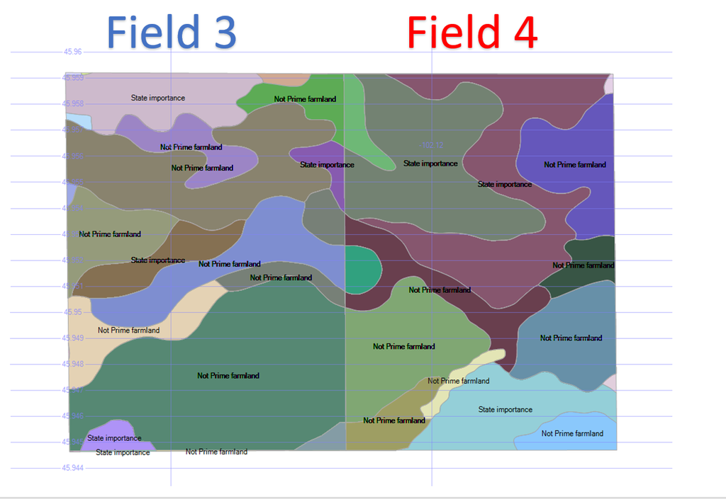

In field 3 the rating is `'Moderate'` with a weaighted average landunit value of `38.96` and in field 4 the rating class is `'Moderate'` and the value is `37.09`.

## Global Soil Organic Carbon Output

The SOCstock for 0–30 cm (high, rv, and low) was exported for further GIS interpolation and extrapolation.

[figure not shown]

Figure 2.—Soil organic carbon stock: Hawaii

[figure not shown]

Figure 3.—Soil organic carbon stock: Puerto Rico

[figure not shown]

## Sources and Citations

The source of this data is STATSGO and SSURGO from the U.S. National Cooperative Soil Survey. The following references cover data definitions, derivation and quality procedures.

1. U.S. Department of Agriculture, Natural Resources Conservation Service. National soil survey handbook, title 430-VI. http://www.nrcs.usda.gov/wps/portal/nrcs/detail/soils/ref/?cid=nrcs142p2_054242 (accessed 13 October 2017).
2. U.S. Department of Agriculture, Natural Resources Conservation Service. 2014. Kellogg Soil Survey Laboratory methods manual (SSIR 42), version 5. https://www.nrcs.usda.gov/wps/portal/nrcs/detail/soils/research/guide/?cid=nrcs142p2_054247 (accessed 23 July 2019).
3. U.S. Department of Agriculture, Natural Resources Conservation Service. 2017a. Soil Data Access; Soil Survey Geographic (SSURGO) Database. https://sdmdataaccess.sc.egov.usda.gov. (accessed 12 October 2017).
4. U.S. Department of Agriculture, Natural Resources Conservation Service. 2017b. Soil Data Access; U.S. General Soil Map (STATSGO2). https://sdmdataaccess.sc.egov.usda.gov (accessed 12 October 2017).
5. Ellert, B.H., H.H. Janzen, A.J. VandenBygaart, and E. Bremer. 2008. Measuring change in soil organic carbon storage. *In:* Carter, M.R., and E.G. Gregorich, editors, Soil sampling and methods of analysis, 2nd edition. CRC Press, Boca Raton, FL, pp. 25–38.